# GSoC2021: tests

Haris Zafeiropoulos

4/11/2021

## From DNA sequences to metabolic interactions: building a pipeline to extract key metabolic processes

Based on previous work, I propose a Google Summer of Code project in the framework of the GeomScale group that is not listed in their [table of proposed coding projects](https://github.com/GeomScale/gsoc2021/wiki/table-of-proposed-coding-projects).

However, as it has a lot in common with the [Inferring microbial interactions](https://github.com/GeomScale/gsoc2021/wiki/Inferring-microbial-interactions) project, this is an implementation of the tests that correspond to the later.

### Easy

*Question:* *Compile and run `volesti`. Use the R extension to visualize sampling in a polytope*

After cloning the [`volume_approximation`](https://github.com/GeomScale/volume_approximation/) repository and checking out to the `branch` of the [`SoCG21`](https://github.com/GeomScale/volume_approximation/tree/socg21)

I installed the [dependencies](https://github.com/GeomScale/volume_approximation/tree/socg21) described there to install this `volesti` version, including some extra, metabolic-networks-oriented functions.

To sample on a polytope, I got an example of a cube polytope from the `R-proj/inst/extdata` directory of the repo. You may find this cube [here](https://github.com/GeomScale/volume_approximation/blob/develop//inst/extdata/cube_10.ext)

```r
library(volesti)
```

```r
library(ggplot2)
setwd("/home/haris/Documents/coding/github_repos/volume_approximation/R-proj/")
polytope = file_to_polytope("examples/cube10.ine")
```

As I chose an `.ine` file, I got a H-polytope. I then checked the dimension of the cube polytope.

```r
polytope$dimension
```

```
## [1] 10
```

Then I sampled on the cube polytope with various random walks supported by the `volesti` library, asking for 10,000 points in every case.

```r
# 'CDHR' for Coordinate Directions Hit-and-Run
points_cdhr =  sample_points(P = polytope, n = 10000,
                             distribution = list("density" = "uniform"),  random_walk = list("walk"="CDHR"))
CDHR = data.frame(x=points_cdhr[1,], y=points_cdhr[2,])

# 'RDHR' for Random Directions Hit-and-Run
points_rdhr =  sample_points(P = polytope, n = 10000,
                             distribution = list("density" = "uniform"),  random_walk = list("walk"="RDHR"))
RDHR = data.frame(x=points_rdhr[1,], y=points_rdhr[2,])

# BiW' for Billiard walk
points_biw =  sample_points(P = polytope, n = 10000,
                            distribution = list("density" = "uniform"),  random_walk = list("walk"="BiW"))
BiW = data.frame(x=points_biw[1,], y=points_biw[2,])

# BaW' for Ball Walk
points_baw =  sample_points(P = polytope, n = 10000,
                            distribution = list("density" = "uniform"),  random_walk = list("walk"="BaW"))
BaW = data.frame(x=points_baw[1,], y=points_baw[2,])

# 'dikin' for dikin walk
points_dikin =  sample_points(P = polytope, n = 10000,
                            distribution = list("density" = "uniform"),  random_walk = list("walk"="dikin"))
dikin = data.frame(x=points_dikin[1,], y=points_dikin[2,])

# 'vaidya' for vaidya walk,
points_vaidya =  sample_points(P = polytope, n = 10000,
                            distribution = list("density" = "uniform"),  random_walk = list("walk"="vaidya"))
vaidya = data.frame(x=points_vaidya[1,], y=points_vaidya[2,])

# 'john' for john walk
points_john =  sample_points(P = polytope, n = 10000,
                            distribution = list("density" = "uniform"),  random_walk = list("walk"="john"))
john = data.frame(x=points_john[1,], y=points_john[2,])

# 'BCDHR' boundary sampling by keeping the extreme points of CDHR
points_BCDHR =  sample_points(P = polytope, n = 10000,
                            distribution = list("density" = "uniform"),  random_walk = list("walk"="BCDHR"))
BCDHR = data.frame(x=points_BCDHR[1,], y=points_BCDHR[2,])
```

And then make a plot to see the distribution of each of these walks!

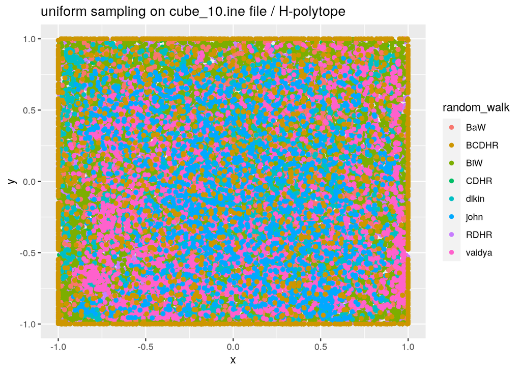

### Medium

*Question:* *Use the R extension to sample on the flux space of the metabolic network of E.coli*

To sample on the flux space of *E.coli*’s metabolic network, we first need to get such a network! :-) Metabolic networks can be usually found as a `.json` or/and a `.xml` or/and a `.mat` file. We will stick with the `.mat` format.

```r
data_url = "http://bigg.ucsd.edu/static/models/e_coli_core.mat"
ecoli_file = "/home/haris/Documents/projects/GeomScale/gsoc2021/e_coli_core.mat"
download.file(data_url, ecoli_file)
```

In order to read this we need to use some libraries.

```r
library(R.matlab)
parse_data_from_mat_file <- function(destination_file) {


  data_from_mat = readMat(destination_file)

  s_matrix = data_from_mat[1]
  s_matrix = s_matrix[[1]]
  s_matrix = matrix(s_matrix, ncol = ncol(s_matrix), nrow = nrow(s_matrix))

  reactions_from_mat = s_matrix[8]
  metabolites_from_mat = s_matrix[1]
  genes_from_mat = s_matrix[5]


  # lb = data_from_mat[6]
  # lb = lb[[1]]
  # d = dim(s_matrix)[2]
  # d = length(lb)
  # A = rbind(diag(d), -diag(d))


  data_object = list(s_matrix, reactions_from_mat, metabolites_from_mat, genes_from_mat)

  return(data_object)
}

new_parse = parse_data_from_mat_file(ecoli_file)
```